# Pathogen-agnostic Sero-analysis Tutorial

If you would like to run the `{SeroTrackR}` R package data processing pipeline for work not relating to the fit-for-purpose tool leveraging eight *Plasmodium vivax* serological exposure markers, then this is the tutorial for you!

## Essential

Please ensure that you have read and prepared your raw Luminex files and plate layout files as per the instructions in the setup vignette.

## Step 1: Read in Raw Data

For this tutorial, we will be using the built-in files within `{SeroTrackR}` that are extrapolated from *Plasmodium vivax* samples.

```r
library(SeroTrackR)
library(tidyverse)

your_raw_data <- c(
  system.file("extdata", "example_MAGPIX_plate1.csv", package = "SeroTrackR"),
  system.file("extdata", "example_MAGPIX_plate2.csv", package = "SeroTrackR"),
  system.file("extdata", "example_MAGPIX_plate3.csv", package = "SeroTrackR")
)
your_plate_layout <- system.file("extdata", "example_platelayout_1.xlsx", package = "SeroTrackR")
```

To run your OWN data, follow the code below and uncomment (i.e., remove the hashtags):

```r
your_raw_data <- c(
  "PATH/TO/YOUR/FILE/plate1.csv",
  "PATH/TO/YOUR/FILE/plate2.csv",
  "PATH/TO/YOUR/FILE/plate3.csv"
)
your_plate_layout <- "PATH/TO/YOUR/FILE/plate_layout.xlsx"
```

You can read any Luminex serology data file using the `readSeroData()` function.

The Luminex platform can be specified using the `platform` argument, with either `bioplex`, `magpix` or `intelliflex`.

For the xPONENT software-based exported files (MAGPIX or INTELLIFLEX), the version of the software should be specified as either **“4.2”** or **“4.3”**, with the version **“4.2”** as the default.

```r
sero_data <- readSeroData(
  raw_data = your_raw_data,
  platform = "magpix",        # default
  version = "4.2"             # default
)
```

```
#> PASS: File example_magpix_plate1.csv successfully validated.
#> PASS: File example_magpix_plate2.csv successfully validated.
#> PASS: File example_magpix_plate3.csv successfully validated.
```

This exports a list of data frames:

1. `data_raw`: The raw, unedited files: A check that the correct file/s were added.
2. `results`: The processed serological data files: Antigen names compatible with the R package, clear columns for each antigen and their MFI results.
3. `counts`: The bead counts detected from the Luminex instrument per antigen, per sample, for each plate.
4. `blanks`: The MFI results for the blank wells.
5. `stds`: The MFI results for the standard curve samples.
6. `run`: The run information from the Luminex machine.

You can access each data frame, for example the `results` data frame, like this:

```r
sero_data$results
```

```
#>      Location     Sample     EBP   LF005   LF010   LF016    MSP8 RBP2b.P87
#> 1     1(1,A1)     Blank1    20.0   200.0    20.0    10.0    20.0      10.0
#> 2     2(1,A2)     Blank2    15.0   291.0    15.0    15.0    15.0      10.0
#> 3     3(1,A3)         S1 15710.5 11990.0 22583.0 21244.0 24306.0    7907.5
#> 4     4(1,A4)         S2 13545.0  8285.0 16947.5 16146.0 17172.0    7186.0
#> 5     5(1,A5)         S3  9767.0  4950.0 10865.0 10621.5 11358.0    4475.5
#> 6     6(1,A6)         S4  5648.5  2519.0  6060.0  5968.5  6237.0    3508.0
#> 7     7(1,A7)         S5  4104.5  1431.0  3711.5  3738.0  3883.5    2082.0
#> 8     8(1,A8)         S6  2105.0   676.5  1889.0  1667.0  2136.0    1102.0
#> 9     9(1,A9)         S7  1107.0   328.0  1106.0   890.0  1204.0     657.0
#> 10  10(1,A10)         S8   452.5   141.0   465.0   405.5   522.0     277.0
#> 11  11(1,A11)         S9   209.0    65.0   206.5   181.5   249.0     138.0
#> 12  12(1,A12)        S10   105.0    42.0   113.5    87.0   134.0      93.0
#> 13   13(1,B1) Unknown013  2712.0  1569.0   673.0   327.0   182.0    1068.0
#> 14   14(1,B2) Unknown014   134.0   378.0   117.0   197.0    58.0     465.5
```

[output cut: 563 more lines]

Next, you need to read in the plate layout! This file will allow us to relabel the raw luminex data from “unknowns” to our study Sample ID’s.

```r
plate_list <- readPlateLayout(
  plate_layout = your_plate_layout,
  sero_data  = sero_data
)
```

```
#> Plate layouts correctly identified!
```

Great! Now our serological data has been processed and our plate layouts are added into R-compatible data frames ready for analysis!

## Step 2: Quality control checks

Quality control checks can also be run on any serological data file that has been processed using the `readSeroData()` and `readPlateLayout()` functions. The `runQC()` function will:

1. Process bead count data (assigns a warning if bead counts are less than 15 or above 500 per antigen).
2. Assign Sample ID’s to Luminex outputs.

```r
qc_results  <- runQC(
  sero_data = sero_data,       # load in your serological data variable
  plate_list = plate_list      # load your plate list variable
)
```

This exports a list of data frames:

1. `processCounts_output`: The bead counts per antigen, per sample, for each plate. Intermediary file for downstream processing. Warning = 0 for pass and = 1 for fail.
2. `getCounts_output`: The processed bead counts file for each sample, summarising whether a sample needs to be repeated. Intermediary file for downstream processing.
3. `sampleid_output`: Aligning the Luminex anonymised data (SampleID) to the plate layout ID’s (Sample). Intermediary file for downstream processing.
4. `getAntigenCounts_output`: The processed bead counts file per antigen per sample. Used for `plotBeadCounts()`.
5. `getCountsQC_output`: The bead counts and QC results per antigen. **Key file**.

You can access each data frame, for example the `getCountsQC_output` data frame, like this:

```r
qc_results$getCountsQC_output
```

```
#> # A tibble: 6 × 20
#>   Location SampleID Plate  EBP_Count EBP_QC LF005_Count LF005_QC LF010_Count
#>   <chr>    <chr>    <chr>      <dbl> <chr>        <dbl> <chr>          <dbl>
#> 1 A1       Blank1   plate1       150 pass            88 pass             184
#> 2 A1       Blank1   plate2       142 pass            85 pass             218
#> 3 A1       Blank1   plate3       150 pass            95 pass             184
#> 4 A10      S8       plate1        50 pass            62 pass              52
#> 5 A10      S8       plate2        50 pass            51 pass              78
#> 6 A10      S8       plate3        52 pass            70 pass              51
#> # ℹ 12 more variables: LF010_QC <chr>, LF016_Count <dbl>, LF016_QC <chr>,
#> #   MSP8_Count <dbl>, MSP8_QC <chr>, PTEX150_Count <dbl>, PTEX150_QC <chr>,
#> #   PvCSS_Count <dbl>, PvCSS_QC <chr>, RBP2b.P87_Count <dbl>,
#> #   RBP2b.P87_QC <chr>, QC_total <chr>
```

You can also visualise QC results using the `sero_data` and `qc_results` variables.

### Standard Curve Plot

The `plotStds()` function plots the standard curve, generated from the antibody data from the standards you indicated in your plate layout (e.g. S1-S10) and Median Fluorescent Intensity (MFI) units are displayed in log10-adjusted scale. In general, the standard curves should look relativel linear (only when the y-axis is on log-adjusted scale).

For your standard curve, you will need to specify the `location = "PNG"`.

*Note*: The argument was originally written to distinguish between PvSEM assays that used different pooled positive control plasma from highly immune adults, which the `location = "ETH"` argument requires a different processing pipeline - here this is irrelevant!

In this plot, there are grey dots in the background. This only appears because we *are* using the PvSEMs in the fit-for-purpose tool and it signifies the standard curve range observed at WEHI. In your dataset, you will not have these grey dots.

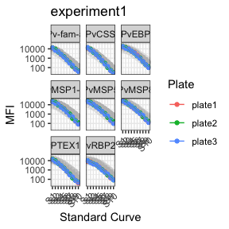

```r
plotStds(sero_data, location = "PNG", experiment_name = "experiment1")
```

For more information on how to interrogate and visualise standard curves, see the Explore Standard Curves page.

### Bead Counts QC Plot

The `plotCounts()` function provides a summary of the bead counts for each plate well are displayed, with blue indicating there are sufficient beads (≥15) or red when there are not enough. If any of the wells are red, they should be double-checked manually and re-run on a new plate if required.

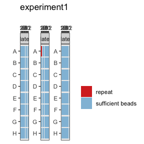

```r
plotCounts(qc_results, experiment_name = "experiment1")
```

```r
getRepeats(qc_results, plate_list)
```

```
#> # A tibble: 2 × 4
#>   Location SampleID Plate  QC
#>   <chr>    <chr>    <chr>  <chr>
#> 1 A1       Blank1   plate2 fail
#> 2 A2       Blank2   plate2 fail
```

The `getRepeats()` function will inform you whether there are “No repeats necessary” or provide a list of samples to be re-run. In the example data, the beads in plate 2 wells A1 and A2 will need to be repeated.

For more information on how to visualise these data, see the Bead Counts page.

### Blanks QC Plot

The Median Fluorescent Intensity (MFI) units for each antigen is displayed for your blank samples. In general, each blank sample should have ≤50 MFI for each antigen, if they are higher they should be cross-checked manually.

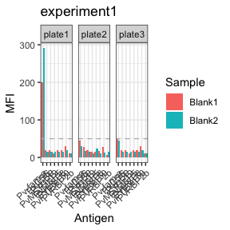

```r
plotBlanks(sero_data, experiment_name = "experiment1")
```

In the example data, blank samples recorded higher MFI values for LF005 on plate 1 and should be checked to confirm this is expected from the assay.